# Matching using R pt.2

# 3. Diagnostics: Check balance and other statistics

Goal: Balance treatment and control groups on $X$

- Common support
- Summary statistics
- Check graphs

## Common support

- matching require some overlaps in $X$
- Example: If you match on sex, some members of your treatment and control must be either male of female.
- Example: All treatment cases are male, all controls are female. You cannot disentangle the effect of participant sex from the treatment effect.
- Can pre-filter to just cases where there is some overlap
- `discard` option in `matchit()`

## Summary statistics

- Balance means that the distribution of $X$ ought to be identical
- Hard to test but we can check summary statistics
- **Standardised difference in means**: Difference in means adjusted for standard deviation (goal: 0)
- **Variance ratio**: treatment group variance divided by control variance (goal: 1)
- **empirical Cumulative Distribution Function (eCDF) mean, variance etc** We want all this to be 0

## Standardised difference in mean

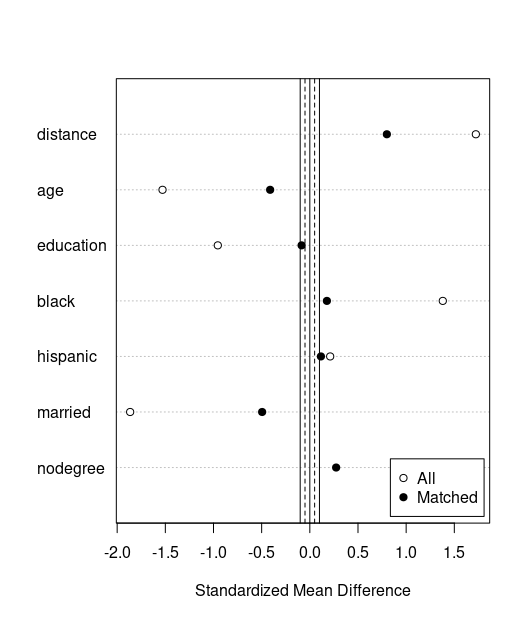

- Vertical lines = 0.1 and 0.05 respectively. You want the matched data to end up within the lines

## QQ plots

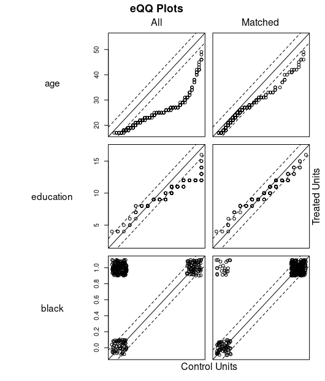

## eCDF plots

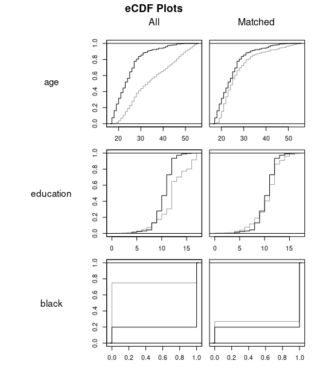

## Remember to check multivariate statistics

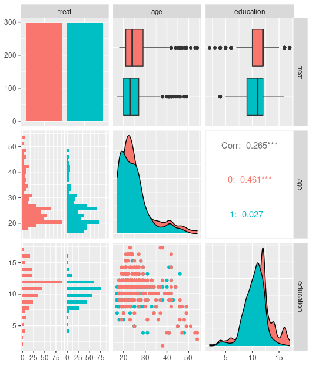

## What to do if balance isn’t good enough

- Official guidance is to iterate and reiterate until balance is good enough.
- Play with more advanced options

## More options

- To prevent poor matches, we can introduce a **caliper** = maxmimum difference between matches.
- A **caliper** of 10% means that matched pair matches cannot have a propensity score difference of more than 10%
- Reduce number of matches in K:1 matching (K = 4 is a good upper limit)
- Do exact matching on some variables first (e.g. split sample into males and females then do propensity score matching)

## Automated matching anyone?

- Coarsened Exact Matching: Like exact matching but uses a rule to create coarsened covariates (think age bands instead of exact ages). Then uses exact matching on the coarsened covariates.
- Genetic matching: Kind of magic. Does a whole series of iterative steps to maximise balance.
- There are a lot of other options ….
- Remember: This is all a means to an end… Balance is key

## Example: Matching jargon

“To avoid poor matches (i.e. large differences between regenerated sites and their closest non-regenerated neighbour) a threshold on the maximum propensity score distance, **the radius**, was imposed (**radius matching**)…. The sample is narrowed to the region of **common support**: regeneration sites with a propensity score higher than the maximum or less than the minimum of the control observations were discarded.”

- Here **radius** means caliper matching

# 4. Estimation

- Get your outcome variable (omitted in step zero)
- Pick whatever model or technique you were going to use
- Add your matching covariates
- Add weights
- Get correct standard errors

## Modelling after matching

- See examples in 04.R
- Always remember to add in weights and matching covariates

## Modelling after matching

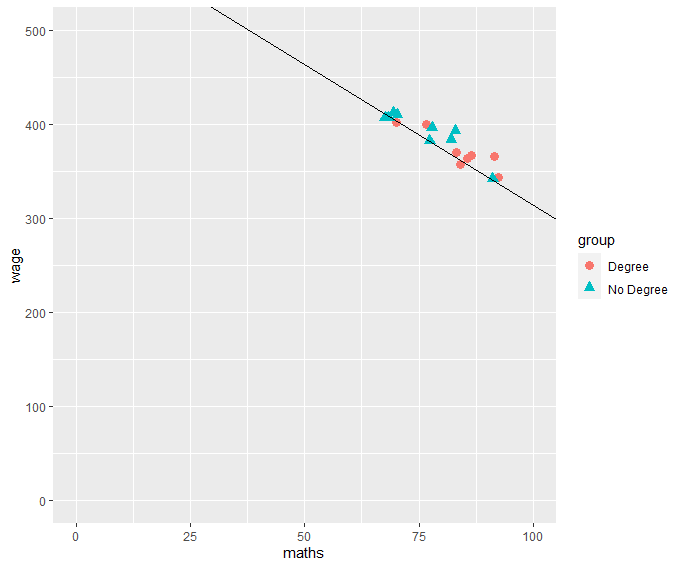

## Correct standard errors

- If in doubt use cluster robust standard errors
- Example: In 1:1 match, each matched pair is a subclass/ cluster. Adjust for this.
- Check cheatsheet

# 5. Posthoc tests

- Robustness tests: Outcome pre-treatment, Placebos
- Get inventive here – I can’t make this up for you
- Remember: The tougher the test is to pass; the more credible your results

# Task 2

- Repeat task 1 but use matching first
- Play around with technique (see cheat sheet) until you are satisfied
- Copy and paste template code (template01 etc)
- What are your new results?